# 01_wet_lab

Gulnara Tagridzhanova

23/10/2024

**Rationale:** to get a reference genome of Trebouxia matching the existing data, I need to isolate photobiont from the thalli

## 1. Isolation from thallus

- 23/10/2024
- Collected X.p. (sample GT0257) from the young oak tree closest to the JIC reception
- Washed in tap water
- Used a dissecting scope to extract algae-enriched pieces of the thallus from the cortex. * Homogenized between a glass slide and a cover slip and washed onto the plates with sterilezed water
- Saved the specimen and also froze some material in -20C
- Incubated on bench for 1 week, then moved to the growth chamber
- In the end, have three plates with Trebouxia:
  - Plate 1: many many Trebouxia colonies, but a lot of fungal growth
  - Plate 2 and 3: only few Trebouxia colonies, but much less contamination
- On 6/12/2024 and 13/12/2024, replated colonies from these plates onto Trebouxia media + rifampicin + carbendazim (20 or 40 mg/mL)
  - all but one replated from plate 1 had fungal contamination
  - from plates 2 and 3 look okay
- On 10/01/2025, selected 4 plates from the 6/12/2024 and 13/12/2024 plates (labelled #1-#4) and restreaked them again on Trebouxia media + rifampicin + carbendazim (20 mg/mL). One of the plates (#1) got contaminated in the process, but all the deriving plates were fine
- On 20/01/2025, re-labelled all ‘good’ plates derived from GT0257 to keep better track. The new numbers are GTP0165-178

## 2. Bulking up

- On 20/01/2025, I made 10 more plates and 10 liquid cultures
  - Plates: Trebouxia media + rif, azoxystrobin, tebucanazole, carbendazim (poured by Jasper)
  - Liquid: Trebouxia media (100 mL) + rif (final concentration 50 ug/mL) + carbendazim (25 ug/mL)
- Selected 5 plates to serve as sources. From each, made 2 plates and 2 liquid cultures:
  - GTP0178 <- GTP0167 (labeled as from GT0257 3 by Jasper) <- GT0257
  - GTP0183 <- GTP0170 (had a colony labelled as #2) <- GTP0165 (labeled as from GT0257 1 by Jasper) <- GT0257
  - GTP0184 <- GTP0170 (had a colony labelled as #2) <- GTP0165 (labeled as from GT0257 1 by Jasper) <- GT0257
  - GTP0190 <- GTP0173 (had a colony labelled as #4) <- GTP0165 (labeled as from GT0257 1 by Jasper) <- GT0257
- The plates received numbers GTP0192-201. The liquid cultures were just labeled with a date and their source
- Put both in the incubator downstairs
- 10 days later, see good growth and no obvious contamination
- On 06/02, subcultured again. Used two flasks: one from GTP0183, one from GTP0191. Split each between four new flasks with the same media as above (Trebouxia + + rif (final concentration 50 ug/mL) + carbendazim (25 ug/mL)). One exception: for one flask from GTP0183 didn’t add antibiotics to test for purity. Five days later, the no-antibiotic flask didn’t seem to have contamination. Will also try plating!

## 3. Id with PCR

- 20-21/01/2025
- From the same plates as were used for inoculating cultures above, took a small sample
- Isolated DNA with Instagene matrix. Didn’t follow some of my previous improvements though:
  - mixed the matrix well, but not on a magnetic block, and didn’t use 1mL tip to add it
  - Used the same block for 56C and 99C incubation and therefore had to wait for the temperature to rise (while waiting the tubes were at room temperature)
  - Extractions labeled as GTX0527-531
- Did PCR on 21/01 (see `analysis_and_temp_files/02_thalli_isolation/2025.01.20_pcr.xslx`)
- Saved sequencing results in `data/sanger_seq/40-1137197568.fasta`
- **Results:**
  - all worked well (except for the poisitive conrol that had a pretty bad sequence quality)
- aligned the good portions of the sequences plus:
  - Asterochloris as an outgroup (PQ160483)
  - rbcL from the plastid genome from GTX0501 assembly. Picked the sequence from contig_257, as it had much higher coverage and therefore most likely belongs to the true photobiont

```r
blastn -query data/sanger_seq/40-1137197568.fasta -subject ../02_long_read_assemblies/data/your-data_fg23028_2023-06-08_0827/FG23028_01.fasta -outfmt 6
GTX0527-Premixed_C16    contig_242  86.906  779 93  8   29  803 119888  119115  0.0 867
GTX0527-Premixed_C16    contig_257  86.504  778 98  7   29  803 182134  182907  0.0 850

samtools faidx ../02_long_read_assemblies/data/your-data_fg23028_2023-06-08_0827/FG23028_01.fasta contig_257:182134-182907
```

```
* saved as `analysis_and_temp_files/02_thalli_isolation/rbcl_pcr.fasta`
```

- made a tree using IQ-TREE webserver, saved as `analysis_and_temp_files/02_thalli_isolation/rbcl_pcr.fasta.contree`
- Renamed the tree

```r
library(ape)
library(ggtree)
tree<-read.tree("../analysis_and_temp_files/01_wet_lab/rbcl_pcr.fasta.contree")

##rename
rename<-data.frame("extraction"=c("GTX0527","GTX0528","GTX0529","GTX0530","GTX0531","PQ160483.1","contig_257_182134"),
                "new"=c("GTP0178 (from GTP0167)",
                       "GTP0183 (from GTP0165)",
                       "GTP0184 (from GTP0165)",
                       "GTP0190 (from GTP0165)",
                       "SAG","PQ160483 Asterochloris",
                       "Xanthoria_thallus"))
rename
```

```
##          extraction                    new
## 1           GTX0527 GTP0178 (from GTP0167)
## 2           GTX0528 GTP0183 (from GTP0165)
## 3           GTX0529 GTP0184 (from GTP0165)
## 4           GTX0530 GTP0190 (from GTP0165)
## 5           GTX0531                    SAG
## 6        PQ160483.1 PQ160483 Asterochloris
## 7 contig_257_182134      Xanthoria_thallus
```

- GTP0178 is on a very long branch compared to others. The three samples that derived from the plate GTP0165 are very close and close to the sequence from a thallus

```r
rename2<-data.frame("old_names"=tree$tip.label,"extraction"=str_split_i(tree$tip.label, "-", 1)) %>% left_join(rename)
```

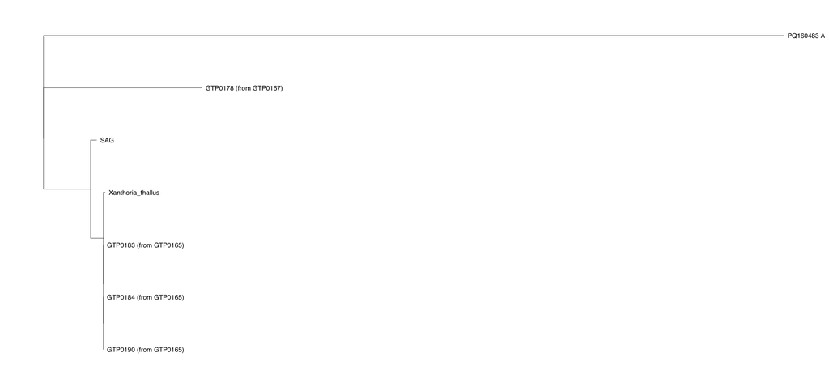

```r
tree$tip.label<-rename2[[3]][match(tree$tip.label, rename2[[1]])]
tree <- root(tree, outgroup = "PQ160483 Asterochloris", resolve.root = TRUE)
ggtree(tree,ladderize = TRUE,right = T,linewidth=0.2)+ geom_tiplab(size=3)
```

- Sequences from the three samples from GTP0165 are exactly identical

```r
library(bio3d)
align <- read.fasta("../analysis_and_temp_files/01_wet_lab/rbcl_pcr.fasta")
pid<-seqidentity(align)
pid[3:6,4:6]
```

```
##                      GTX0530-Premixed_M14 GTX0528-Premixed_E16
## GTX0531-Premixed_K14                0.986                0.986
## GTX0530-Premixed_M14                1.000                1.000
## GTX0528-Premixed_E16                1.000                1.000
## GTX0529-Premixed_A16                1.000                1.000
##                      GTX0529-Premixed_A16
## GTX0531-Premixed_K14                0.986
## GTX0530-Premixed_M14                1.000
## GTX0528-Premixed_E16                1.000
## GTX0529-Premixed_A16                1.000
```

- Comparing our SAG sequence to the ‘official’ (EU123967, reverse complement): 99% identical
- **Will continue with the cultures deriving from GTP0165 as they seem most consistent with the true photobiont**

## 4. Prepare material for sending to SAG

- 27/02/2025
- Poured BMM to make slopes in skirted 50 mL falcons
- Got one flask from GTP1083 from 06/02/2025
- Centrifuged ~40 mL of the cultures at 4,200g for 4 min
- Used sterile pasteur pipette to inoculate the slopes
- Made 15 for GTP0183
- Three GTP0183 slopes were sent to SAG

## 5. Microscopy

- 24/02/2025
- Did microscopy from liquid culture of GTP0183
- Used same settings as for:
  - Argon 514 nm on 10.00 intensity (30% on the configuration)
  - Chlorophyll: 100 gain, 675-750 nm

## 6. Harvesting material for DNA and RNA extractions

#### First

- 14/02/2025
- Used two flasks from each sample:
  - for GTP0183: one from 20/01/2025 and one from 6/02/2025
  - for SAG: one from 18/11/2924 and one from 20/01/2025
- Split them between falcon tubes, span at 4,000rpm for 5 min and removed supernatant
- In the end, put into 3 1.5mL tubes for GTP0183 and 4 tubes for SAG
- Started freeze-drying for 3 days. After that, each tube contained ~80 mg of dry material
- Under a microscope, GTP0183 looked completely like Trebouxia and healthy. SAG looked a bit weird: brown with some transparent cells

#### Second

- 19/02/2025
- for each, harvested flask from 6/02/2025
- got three tubes from each. One of them was snap frozen and put in -80 for future use
- In this flask, SAG looked just as green and healthy as GTP0183

## 7. DNA isolation

- All done with Nucleobond HMW kit
- 19/02/2025
- Did two reactions
- GTP0183_old:
  - Took again one tube from GTP0183 from 14/02/2025
  - Snap frozen and pulverized with Geno/grinder at 1,300 rpm for 1 min
  - Split each tube into two. Added 900 uL of H1 buffer + 100 uL of Protease K
  - Incubated at 50C temperature for 30 min
  - Spinned for 2 min at 11,000, and combined supernatants from initial tubes in 50 mL falcons. Topped up to 5 mL by adding 3 mL of H1
  - Proceeded with the extraction according to the protocol
- GTP0183_new:
  - Took one tube GTP0183 from 19/02/2025
  - These were not freeze-dried and contained ~150 mg wet mass each
  - Snap frozen and pulverized with Geno/grinder at 1,300 rpm for 1 min
  - Added 900 uL of H1 buffer + 200 uL of Protease K
  - Incubated at 50C temperature for 30 min
  - Spinned for 2 min at 11,000, transferred supernatants to 50 mL falcons. Topped up to 5 mL by adding 4 mL of H1
- Proceeded with the extraction according to the protocol until the DNA precipitation step. After mixing DNA elute with isopropanol, left the tubes in the coldroom overnight
- Next morining, centrifuged the mixture for 30 min (instead of 10)
- Left DNA to resuspend in HE buffer for ~1.5h
- Got good results!

```r
df <- data.frame("Extraction ID" = c("GTX0536","GTX0538"),
                 "Source" = c("GTP0183 harvested 14/02","GTP0183 harvested 19/02"),
                 "Nanodrop concentration, ng/uL" = c(139,41),
                 "A260/A230" = c(1.92,1.85),
                 "A260/A230" = c(2,1.36))
df %>%
   kable(format = "html", col.names = colnames(df)) %>%
  kable_styling() %>%
  kableExtra::scroll_box(width = "100%", height = "300px")
```

| Extraction.ID | Source | Nanodrop.concentration..ng.uL | A260.A230 | A260.A230.1 |
| --- | --- | --- | --- | --- |
| GTX0536 | GTP0183 harvested 14/02 | 139 | 1.92 | 2.00 |
| GTX0538 | GTP0183 harvested 19/02 | 41 | 1.85 | 1.36 |

## 8. RNA extraction

#### Initial extraction

- 19/02/2025
- Snap-froze one tube of GTP0183 harvested on 19/02
- Freeze-dried for ~4 h
- Extracted using RNEasy Plant Mini Kit, following instructions including the DNA digestion step. Used old kit and old DNAse (from November 2022). The DNAse was stored as aliquote in -20 in my PCR reagents box, which I basically never take out. It was likely left undisturbed since January 2023 (minus times when I cleaned my drawer). I therefore decided to trust it.
- Split into two reactions
- Results (each is ~30 uL) according to Nanodrop:

```r
df <- data.frame("Extraction ID" = c("GTX0532","GTX0533"),
                 "Nanodrop concentration, ng/uL" = c(474,475))
df %>%
   kable(format = "html", col.names = colnames(df)) %>%
  kable_styling() %>%
  kableExtra::scroll_box(width = "100%", height = "300px")
```

| Extraction.ID | Nanodrop.concentration..ng.uL |
| --- | --- |
| GTX0532 | 474 |
| GTX0533 | 475 |

#### Send to Novogen for sequencing

- Used the DNA re-digested extractions
- Sent to Novogen on 26/02

```r
df <- data.frame("Extraction ID" = c("GTX0532"),
                 "Strain" = c("GTP0183"),
                 "Source" = c("Flask 06/02/2025"),
                 "Nanodrop concentration, ng/uL" = c(380),
                 "A260/A230" = c(2.21),
                 "A260/A230" = c(1.83),
                 "Volume sent, uL" = c(20),
                 "DNA mass, ug" = c(380*20/1000),
                 "Volume left, uL" = c(10))

df %>%
   kable(format = "html", col.names = colnames(df)) %>%
  kable_styling() %>%
  kableExtra::scroll_box(width = "100%", height = "150px")
```

| Extraction.ID | Strain | Source | Nanodrop.concentration..ng.uL | A260.A230 | A260.A230.1 | Volume.sent..uL | DNA.mass..ug | Volume.left..uL |
| --- | --- | --- | --- | --- | --- | --- | --- | --- |
| GTX0532 | GTP0183 | Flask 06/02/2025 | 380 | 2.21 | 1.83 | 20 | 7.6 | 10 |